# Homework 05

Set a random seed before each simulation question and report it. You may use standard packages unless a question asks you to write the calculation yourself. Use equal neighbor weights throughout. Here $p$ counts the covariates used to measure distance; do not add an intercept column to a KNN predictor matrix. R and Python use different random-number generators, so their exact simulation results need not agree.

## Question 1: Estimate the bias and variance of KNN

In our previous homework, we used repeated simulations to study the behavior of linear regression estimators. We will now use the same idea for KNN. Consider the regression model

$$Y_i=f(\mathbf X_i)+\epsilon_i,
\qquad
f(\mathbf x)=0.5x_1+\sin(x_2)-0.3x_3^2,$$

where the three covariates are independent standard normal variables and $\epsilon_i\sim\mathcal N(0,0.1^2)$ independently of the covariates and other observations. Generate $n=400$ training observations. Our goal is to estimate the mean response at

$$\mathbf x_0=(0.5,0.7,1)^{\mathsf T}.$$

Use Euclidean distance and consider $k=1,3,5,\ldots,29$.

1. Calculate $f(\mathbf x_0)$. Generate one training dataset and obtain the KNN prediction at $\mathbf x_0$ for each value of $k$.
2. Independently repeat the generation of the training covariates and responses 200 times. Within each repetition, use the same training data for every value of $k$. Store the predictions in a matrix with 200 rows and one column for each value of $k$. Use this matrix to estimate the bias, variance, and mean squared error of the estimated mean response. Use divisor 200 when calculating the empirical variance, and verify numerically that

$$\text{mean squared error}
=\text{squared bias}+\text{variance}.$$

Plot squared bias, variance, and mean squared error against $k$ in one figure. Explain the pattern and compare it with the bias-variance trade-off for ridge regression or lasso.

### Solution: Question 1

**Show the workflow**

```r
set.seed(432)

x0 <- c(0.5, 0.7, 1)

f_x0 <- 0.5 * x0[1] + sin(x0[2]) - 0.3 * x0[3]^2

n <- 400

X <- matrix(rnorm(n * 3), nrow = n, ncol = 3)

epsilon <- rnorm(n, mean = 0, sd = 0.1)

y <- 0.5 * X[, 1] + sin(X[, 2]) - 0.3 * X[, 3]^2 + epsilon

distances <- sqrt(rowSums((X - matrix(x0, nrow = n, ncol = 3, byrow = TRUE))^2))

neighbor_order <- order(distances)

k_values <- seq(1, 29, by = 2)

knn_predictions <- sapply(k_values, function(k) {
  neighbors <- neighbor_order[1:k]
  mean(y[neighbors])
})

knn_predictions
```

```
 [1] 0.7519783 0.7519608 0.5437195 0.4585557 0.4823139 0.4086601 0.4540832
 [8] 0.5076791 0.5448164 0.5170615 0.4974853 0.5477527 0.5455409 0.4761778
[15] 0.4562999
```

**Show the workflow**

```r
data.frame(
  k = k_values,
  prediction = knn_predictions
)
```

```
    k prediction
1   1  0.7519783
2   3  0.7519608
3   5  0.5437195
4   7  0.4585557
5   9  0.4823139
6  11  0.4086601
7  13  0.4540832
8  15  0.5076791
9  17  0.5448164
10 19  0.5170615
11 21  0.4974853
12 23  0.5477527
13 25  0.5455409
14 27  0.4761778
15 29  0.4562999
```

**Show the workflow**

```r
B <- 200

predictions <- matrix(NA, nrow = B, ncol = length(k_values))

for (b in 1:B) {

  X <- matrix(rnorm(n * 3), nrow = n, ncol = 3)

  epsilon <- rnorm(n, mean = 0, sd = 0.1)

  y <- 0.5 * X[, 1] +
    sin(X[, 2]) -
    0.3 * X[, 3]^2 +
    epsilon

  distances <- sqrt(
    rowSums((X - matrix(x0, nrow = n, ncol = 3, byrow = TRUE))^2)
  )

  neighbor_order <- order(distances)

  predictions[b, ] <- sapply(k_values, function(k) {
    neighbors <- neighbor_order[1:k]
    mean(y[neighbors])
  })
}

mean_predictions <- colMeans(predictions)

bias <- mean_predictions - f_x0

data.frame(
  k = k_values,
  bias = bias
)
```

```
    k        bias
1   1 -0.01913146
2   3 -0.04698232
3   5 -0.04412943
4   7 -0.05321234
5   9 -0.05686494
6  11 -0.06449760
7  13 -0.07056518
8  15 -0.07500571
9  17 -0.08379625
10 19 -0.09257223
11 21 -0.09750234
12 23 -0.10205093
13 25 -0.10673394
14 27 -0.11388942
15 29 -0.12075028
```

**Show the workflow**

```r
variance <- colMeans(
  (predictions - matrix(mean_predictions,
                        nrow = B,
                        ncol = length(k_values),
                        byrow = TRUE))^2
)

data.frame(
  k = k_values,
  variance = variance
)
```

```
    k    variance
1   1 0.041992749
2   3 0.018831832
3   5 0.012355354
4   7 0.010572281
5   9 0.008812774
6  11 0.008318164
7  13 0.008286064
8  15 0.007726893
9  17 0.007222258
10 19 0.007192481
11 21 0.006798363
12 23 0.006806483
13 25 0.006751709
14 27 0.006271337
15 29 0.006442344
```

**Show the workflow**

```r
bias_squared <- bias^2

data.frame(
  k = k_values,
  bias_squared = bias_squared
)
```

```
    k bias_squared
1   1 0.0003660126
2   3 0.0022073388
3   5 0.0019474065
4   7 0.0028315527
5   9 0.0032336209
6  11 0.0041599403
7  13 0.0049794445
8  15 0.0056258568
9  17 0.0070218122
10 19 0.0085696184
11 21 0.0095067061
12 23 0.0104143917
13 25 0.0113921348
14 27 0.0129708011
15 29 0.0145806302
```

**Show the workflow**

```r
mse <- colMeans((predictions - f_x0)^2)

data.frame(
  k = k_values,
  mse = mse
)
```

```
    k        mse
1   1 0.04235876
2   3 0.02103917
3   5 0.01430276
4   7 0.01340383
5   9 0.01204640
6  11 0.01247810
7  13 0.01326551
8  15 0.01335275
9  17 0.01424407
10 19 0.01576210
11 21 0.01630507
12 23 0.01722087
13 25 0.01814384
14 27 0.01924214
15 29 0.02102297
```

**Show the workflow**

```r
bias_variance <- bias_squared + variance

data.frame(
  k = k_values,
  mse = mse,
  bias_squared = bias_squared,
  variance = variance,
  bias_squared_plus_variance = bias_variance
)
```

```
    k        mse bias_squared    variance bias_squared_plus_variance
1   1 0.04235876 0.0003660126 0.041992749                 0.04235876
2   3 0.02103917 0.0022073388 0.018831832                 0.02103917
3   5 0.01430276 0.0019474065 0.012355354                 0.01430276
4   7 0.01340383 0.0028315527 0.010572281                 0.01340383
5   9 0.01204640 0.0032336209 0.008812774                 0.01204640
6  11 0.01247810 0.0041599403 0.008318164                 0.01247810
7  13 0.01326551 0.0049794445 0.008286064                 0.01326551
8  15 0.01335275 0.0056258568 0.007726893                 0.01335275
9  17 0.01424407 0.0070218122 0.007222258                 0.01424407
10 19 0.01576210 0.0085696184 0.007192481                 0.01576210
11 21 0.01630507 0.0095067061 0.006798363                 0.01630507
12 23 0.01722087 0.0104143917 0.006806483                 0.01722087
13 25 0.01814384 0.0113921348 0.006751709                 0.01814384
14 27 0.01924214 0.0129708011 0.006271337                 0.01924214
15 29 0.02102297 0.0145806302 0.006442344                 0.02102297
```

**Show the workflow**

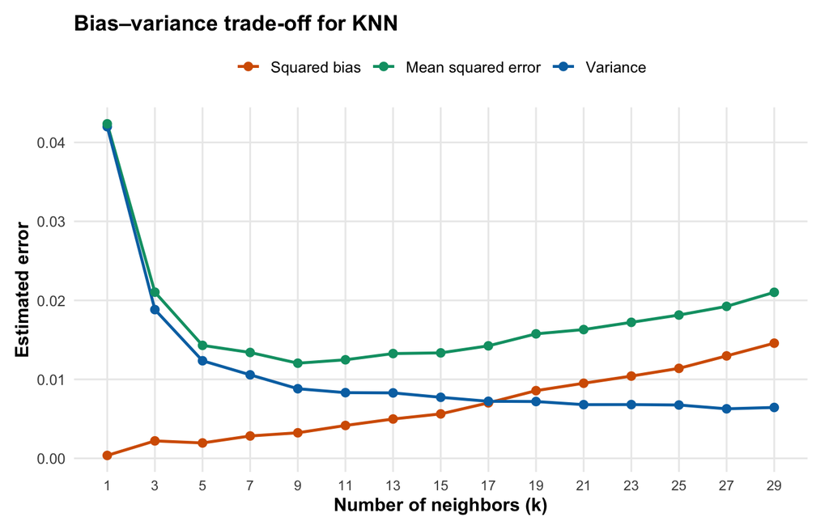

```r
results <- data.frame(
  k = k_values,
  bias_squared = bias_squared,
  variance = variance,
  mse = mse
)

library(ggplot2)
library(tidyr)

results_long <- pivot_longer(
  results,
  cols = c(bias_squared, variance, mse),
  names_to = "quantity",
  values_to = "value"
)

ggplot(results_long, aes(x = k, y = value, color = quantity)) +
  geom_line(linewidth = 0.9) +
  geom_point(size = 2.2) +
  scale_x_continuous(breaks = k_values) +
  scale_color_manual(
    values = c(
      bias_squared = "#D55E00",
      variance = "#0072B2",
      mse = "#009E73"
    ),
    labels = c(
      bias_squared = "Squared bias",
      variance = "Variance",
      mse = "Mean squared error"
    )
  ) +
  labs(
    title = "Bias–variance trade-off for KNN",
    x = "Number of neighbors (k)",
    y = "Estimated error",
    color = NULL
  ) +
  theme_minimal(base_size = 12) +
  theme(
    plot.title = element_text(face = "bold", size = 14),
    axis.title = element_text(face = "bold"),
    axis.text.x = element_text(size = 9),
    legend.position = "top",
    legend.text = element_text(size = 10),
    panel.grid.minor = element_blank(),
    plot.margin = margin(10, 14, 10, 10)
  )
```

$f(x_0) = 0.5942$

The estimated MSE was approximately equal to the squared bias plus the variance for each value of k. This confirms the bias-variance decomposition using the 200 simulated training sets. As k increases, the variance decreases because the prediction is based on more observations. At the same time, the squared bias generally increases because larger values of k include observations that are farther away from $x_0$. This creates a bias-variance tradeoff, which is why the MSE is lowest somewhere in the middle. This is similar to ridge and lasso because increasing the penalty makes the model less flexible, which generally decreases variance but increases bias.

## Question 2: Compare KNN with lasso

Use the response model from Question 1, including the noise standard deviation $0.1$, but generate $p=30$ covariates. The response still depends only on the first three. Consider these two settings:

- **Setting 1:** all 30 covariates are independent standard normal variables.
- **Setting 2:** the covariates have a multivariate normal distribution with mean zero and covariance matrix $\boldsymbol\Sigma$, where

  $$\Sigma_{jj}=1,
  \qquad
  \Sigma_{jl}=0.8\quad\text{for }j\ne l.$$

In each setting, generate 400 training observations and 1,000 independent test observations. Fit 5NN using Euclidean distance on the supplied covariate scale. All covariates already have population variance one.

For lasso, use a linear model containing the 30 covariates and a separately fitted, unpenalized intercept. Follow the Week 4 objective,

$$L_\lambda(\boldsymbol\beta)
=\frac{1}{2n}\left\lVert
\widetilde{\mathbf y}-\mathbf X\boldsymbol\beta
\right\rVert_2^2
+\lambda\lVert\boldsymbol\beta\rVert_1,$$

where $\mathbf X\in\mathbb R^{n\times30}$ contains the centered and standardized covariates and $\widetilde{\mathbf y}$ is the centered training response. Select the penalty by ten-fold cross-validation over 41 logarithmically spaced values from $10^{-4}$ to $1$. Estimate all means and scales using only the training portion of each fold, with divisor equal to that portion’s sample size. After selecting the penalty, refit on all training observations and apply the fitted transformations unchanged to the test observations. Do not add nonlinear terms to the lasso model.

1. Fit both methods in each setting. Use the same training and test data for the two methods within a setting. Report their test MSE values in one table, together with the selected lasso penalty and the number of nonzero lasso slopes. You only need to generate one dataset for each setting; repeated simulations are not required.
2. Compare the results between the two settings. Explain how correlation can change the usefulness of Euclidean neighborhoods, and why lasso does not use all covariates in the same way as KNN.
3. The response model contains $\sin(X_2)$ and $X_3^2$, but the lasso fit uses only linear terms. Explain how this difference affects the comparison. Would the results justify a general claim that correlation always helps KNN, or that one method is always better? Explain why.

### Solution: Question 2

**Show the workflow**

```r
set.seed(432)

library(FNN)
library(glmnet)
```

**Show the workflow**

```r
n <- 400
p <- 30
lambda <- 10^seq(0, -4, length.out = 41)

results <- data.frame(
  Setting = c("Independent", "Correlated"),
  KNN_MSE = NA_real_,
  Lasso_MSE = NA_real_,
  Lambda = NA_real_,
  Nonzero = NA_integer_
)

for (l in 1:2) {

  Sigma <- diag(p)

  if (l == 2) {
    Sigma <- 0.8 + 0.2 * diag(p)
  }

  X <- matrix(rnorm((n + 1000) * p), ncol = p) %*% chol(Sigma)

  y <- 0.5 * X[, 1] +
    sin(X[, 2]) -
    0.3 * X[, 3]^2 +
    rnorm(n + 1000, sd = 0.1)

  test.X <- X[(n + 1):(n + 1000), ]
  test.y <- y[(n + 1):(n + 1000)]

  X <- X[1:n, ]
  y <- y[1:n]

  knn.fit <- knn.reg(
    X,
    test.X,
    y,
    k = 5,
    algorithm = "brute"
  )

  results$KNN_MSE[l] <- mean(
    (test.y - knn.fit$pred)^2
  )

  fold <- sample(rep(1:10, each = n / 10))

  cv.mse <- matrix(
    NA_real_,
    nrow = 10,
    ncol = length(lambda)
  )

  for (m in 1:10) {

    X.mean <- colMeans(X[fold != m, ])

    X.fit <- sweep(
      X[fold != m, ],
      2,
      X.mean,
      "-"
    )

    X.sd <- sqrt(colMeans(X.fit^2))

    X.fit <- sweep(
      X.fit,
      2,
      X.sd,
      "/"
    )

    X.valid <- sweep(
      X[fold == m, ],
      2,
      X.mean,
      "-"
    )

    X.valid <- sweep(
      X.valid,
      2,
      X.sd,
      "/"
    )

    y.mean <- mean(y[fold != m])

    lasso.fit <- glmnet(
      X.fit,
      y[fold != m] - y.mean,
      alpha = 1,
      lambda = lambda,
      intercept = FALSE,
      standardize = FALSE
    )

    y.hat <- predict(
      lasso.fit,
      newx = X.valid,
      s = lambda
    ) + y.mean

    cv.mse[m, ] <- colMeans(
      (y[fold == m] - y.hat)^2
    )
  }

  lambda.min <- lambda[
    which.min(colMeans(cv.mse))
  ]

  X.mean <- colMeans(X)

  X.fit <- sweep(
    X,
    2,
    X.mean,
    "-"
  )

  X.sd <- sqrt(colMeans(X.fit^2))

  X.fit <- sweep(
    X.fit,
    2,
    X.sd,
    "/"
  )

  test.X.fit <- sweep(
    test.X,
    2,
    X.mean,
    "-"
  )

  test.X.fit <- sweep(
    test.X.fit,
    2,
    X.sd,
    "/"
  )

  y.mean <- mean(y)

  lasso.fit <- glmnet(
    X.fit,
    y - y.mean,
    alpha = 1,
    lambda = lambda,
    intercept = FALSE,
    standardize = FALSE
  )

  test.pred <- as.vector(
    predict(
      lasso.fit,
      newx = test.X.fit,
      s = lambda.min
    )
  ) + y.mean

  results$Lasso_MSE[l] <- mean(
    (test.y - test.pred)^2
  )

  results$Lambda[l] <- lambda.min

  results$Nonzero[l] <- sum(
    coef(lasso.fit, s = lambda.min)[-1, 1] != 0
  )
}

results
```

```
      Setting   KNN_MSE Lasso_MSE     Lambda Nonzero
1 Independent 0.5893325 0.2393865 0.02511886      10
2  Correlated 0.1794839 0.2660958 0.02511886       5
```

For the independent setting, 5NN had a test MSE of 0.5893, while lasso had a test MSE of 0.2394. The selected value of $\lambda$ was 0.0251, and the lasso model had 10 nonzero slopes. For the correlated setting, 5NN had a test MSE of 0.1795, while lasso had a test MSE of 0.2661. The selected value of $\lambda$ was again 0.0251, and the lasso model had 5 nonzero slopes.

5NN performed much better when the predictors were correlated, with its test MSE decreasing from 0.5893 to 0.1795. When the predictors are independent, KNN has to calculate distances using all 30 dimensions, even though only the first three predictors directly affect the response. When the predictors are highly correlated, there is less unique information across the 30 dimensions, so the data effectively behaves like it has a lower dimension. This makes the distances between observations more meaningful for KNN. Lasso performed slightly worse in the correlated setting, and it also selected fewer nonzero slopes.

The true response is nonlinear because it includes $\sin(X_2)$ and $X_3^2$, while the lasso model only includes linear terms. This puts lasso at a disadvantage because it cannot directly represent the true relationship. KNN does not assume a linear relationship, so it can better capture this nonlinearity when distances between observations are meaningful. However, these results do not mean that correlated predictors will always improve KNN or that KNN will always perform better than lasso. The performance of each method depends on factors such as the relationship between the predictors and response, the number of predictors, and the correlation structure.

## Question 3: Observed dimension and latent dimension

The lecture’s handwritten digit example shows that KNN can work with many measured covariates. We will use a simulation to investigate why the structure of those covariates matters.

Let $p=100$ be the number of observed covariates and let $m$ be the number of latent variables. For each observation, generate

$$\mathbf X_i=\mathbf A\mathbf Z_i+\boldsymbol\eta_i,
\qquad
Y_i=Z_{i1}+Z_{i2}+\epsilon_i,$$

where $\mathbf A\in\mathbb R^{100\times m}$ has independent entries from Uniform$[-2,2]$. The entries of $\mathbf Z_i\in\mathbb R^m$ and $\boldsymbol\eta_i\in\mathbb R^{100}$, and the scalar $\epsilon_i$, are independent standard normal variables, also independent of $\mathbf A$. Generate $\mathbf A$ once and use it for all training and test observations in that dataset.

Compare $m=3$ and $m=30$. In each setting, generate 200 training observations and 200 independent test observations. Fit KNN using only the 100 observed covariates in $\mathbf X$, with Euclidean distance on their generated scale. The latent variables in $\mathbf Z$ are used to generate the data but are not available to the fitted model. Consider $k=2,10,18,\ldots,82$.

1. Generate one dataset for each value of $m$. Fit KNN for every value of $k$ and calculate test MSE. Within a setting, use the same training and test observations for all values of $k$.
2. Repeat the complete experiment 50 times, generating a new $\mathbf A$ and new observations in each repetition. Plot average test MSE against $k$, with one curve for each value of $m$. These curves compare the specified choices of $k$ in a controlled simulation; they are not a cross-validation procedure for selecting a final model.
3. Both settings have 100 observed covariates, and the response depends on only two latent variables. Explain why their KNN performance can still differ. What role does the noise $\boldsymbol\eta_i$ play, and why are the observed data not confined exactly to an $m$-dimensional linear space?

### Solution: Question 3

**Show the workflow**

```r
set.seed(432)

library(FNN)

p <- 100
m_values <- c(3, 30)
k_values <- seq(2, 82, by = 8)

test_mse <- matrix(
  NA,
  nrow = length(k_values),
  ncol = length(m_values)
)

for (j in seq_along(m_values)) {

  m <- m_values[j]

  A <- matrix(rnorm(p * m), nrow = p, ncol = m)

  Z <- matrix(rnorm(400 * m), nrow = 400, ncol = m)

  eta <- matrix(rnorm(400 * p, sd = 0.2), nrow = 400, ncol = p)

  X <- Z %*% t(A) + eta

  y <- Z[, 1] + Z[, 2] + rnorm(400, sd = 0.5)

  X_train <- X[1:200, ]
  X_test <- X[201:400, ]

  y_train <- y[1:200]
  y_test <- y[201:400]

  for (i in seq_along(k_values)) {

    k <- k_values[i]

    knn_fit <- knn.reg(
      train = X_train,
      test = X_test,
      y = y_train,
      k = k
    )

    test_mse[i, j] <- mean((y_test - knn_fit$pred)^2)
  }
}

colnames(test_mse) <- c("m = 3", "m = 30")

data.frame(
  k = k_values,
  test_mse
)
```

```
    k     m...3   m...30
1   2 0.5801660 2.253006
2  10 0.4497447 1.823784
3  18 0.4943162 1.859505
4  26 0.5169409 1.942522
5  34 0.5627608 1.960586
6  42 0.6187043 1.992770
7  50 0.6712849 2.038844
8  58 0.7307000 2.096596
9  66 0.8028021 2.105015
10 74 0.8592744 2.138561
11 82 0.9282970 2.186170
```

**Show the workflow**

```r
B <- 50

mse_array <- array(
  NA,
  dim = c(B, length(k_values), length(m_values))
)

for (b in 1:B) {

  for (j in seq_along(m_values)) {

    m <- m_values[j]

    A <- matrix(rnorm(p * m), nrow = p, ncol = m)

    Z <- matrix(rnorm(400 * m), nrow = 400, ncol = m)

    eta <- matrix(
      rnorm(400 * p, sd = 0.2),
      nrow = 400,
      ncol = p
    )

    X <- Z %*% t(A) + eta

    y <- Z[, 1] + Z[, 2] + rnorm(400, sd = 0.5)

    X_train <- X[1:200, ]
    X_test <- X[201:400, ]

    y_train <- y[1:200]
    y_test <- y[201:400]

    for (i in seq_along(k_values)) {

      knn_fit <- knn.reg(
        train = X_train,
        test = X_test,
        y = y_train,
        k = k_values[i]
      )

      mse_array[b, i, j] <- mean(
        (y_test - knn_fit$pred)^2
      )
    }
  }
}

mean_mse <- apply(mse_array, c(2, 3), mean)

colnames(mean_mse) <- c("m = 3", "m = 30")

data.frame(
  k = k_values,
  mean_mse
)
```

```
    k     m...3   m...30
1   2 0.4964816 1.919246
2  10 0.4328549 1.531484
3  18 0.4913153 1.563348
4  26 0.5514755 1.601443
5  34 0.6125681 1.637475
6  42 0.6717459 1.672736
7  50 0.7289036 1.707745
8  58 0.7876187 1.740173
9  66 0.8472481 1.771413
10 74 0.9076075 1.800343
11 82 0.9691319 1.828537
```

**Show the workflow**

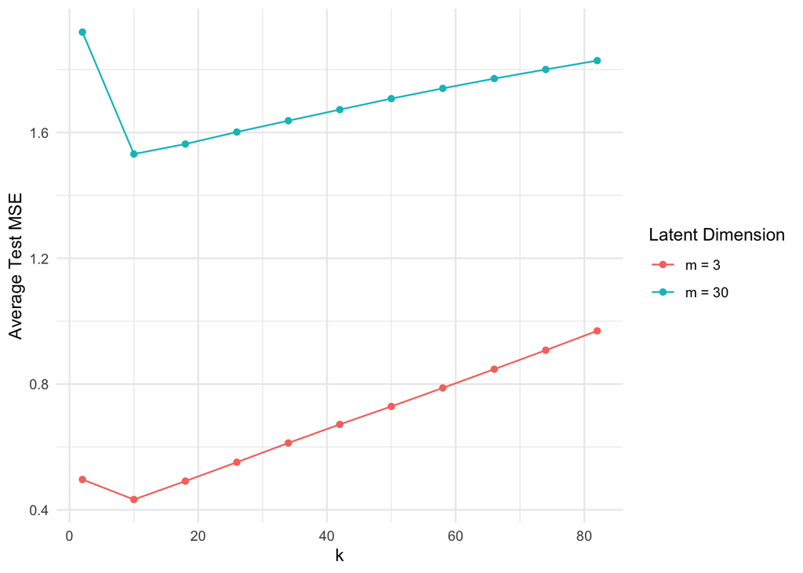

```r
plot_data <- data.frame(
  k = rep(k_values, 2),
  mse = c(mean_mse[, 1], mean_mse[, 2]),
  m = rep(c("m = 3", "m = 30"), each = length(k_values))
)

ggplot(plot_data, aes(x = k, y = mse, color = m)) +
  geom_line() +
  geom_point() +
  labs(
    x = "k",
    y = "Average Test MSE",
    color = "Latent Dimension"
  ) +
  theme_minimal()
```

The test MSEs for each value of k are shown in the table above. For m=3, the lowest test MSE was 0.4497 at k=10. For m=30, the lowest test MSE was 1.8238 at k=10.

After averaging the test MSE across 50 simulations, m=3 had a lower test MSE than m=30 for every value of k. For both values of m, the average test MSE was lowest around k=10 and then increased as k became larger.

Even though both settings have 100 observed predictors, the underlying dimension of the data is different. When m=3, most of the structure in the 100 predictors comes from only 3 latent variables. This makes it easier for KNN to find observations that are actually close to each other. When m=30, the data varies across many more latent dimensions, so distances become less informative and KNN has a harder time finding useful neighbors. This explains why the test MSE is much higher for m=30. The noise term $\eta$ also adds variation to each observed predictor, so the observations do not lie perfectly in an m-dimensional subspace, which makes finding close neighbors more difficult.

## Question 4: Classify handwritten digits

Use `zip.train` and `zip.test` from the R package `ElemStatLearn`, as in the lecture. The package has been retired from the active CRAN repository. If needed, install the [archived package](https://cran.r-project.org/src/contrib/Archive/ElemStatLearn/ElemStatLearn_2015.6.26.2.tar.gz) into your usual R library, then load the two datasets. Python users can use the course copies of the same [training data](https://teazrq.github.io/stat432rpy/data/knn/zip-train.csv.gz) and [test data](https://teazrq.github.io/stat432rpy/data/knn/zip-test.csv.gz). These compressed CSV files have no headers and are included in the homework ZIP under `data/knn`. Run the Python code from the folder containing `data`.

Each image has $16\times16=256$ pixel values. The first column is the digit label and the remaining columns are the pixel values. Use the first 1,000 rows of `zip.train` and the first 500 rows of `zip.test`. Use the original pixel values without standardization, and do not include the digit label in a distance calculation.

For a test image $\mathbf x_0$ and a training image $\mathbf x_i$, the two distances are

$$d_E(\mathbf x_0,\mathbf x_i)
=\sqrt{\sum_{j=1}^{256}(x_{0j}-x_{ij})^2},
\qquad
d_M(\mathbf x_0,\mathbf x_i)
=\sum_{j=1}^{256}|x_{0j}-x_{ij}|.$$

1. Write a 5NN classification function that allows either Euclidean or Manhattan distance. For each test image, calculate its distances to the training images directly, find the five nearest, and return the most frequent digit label. Break distance ties by the smaller training row number and voting ties by the smallest digit. Do not use a built-in distance or KNN function for this part.
2. Apply the classifier to all 500 test images using each distance. For each fit, report the test classification error and a $10\times10$ confusion matrix, with rows representing predicted digits and columns representing true digits. Keep all digit labels from 0 through 9 in the matrix, including any with a zero count. Which digits are most often confused with one another?
3. For Euclidean distance, display three incorrectly classified test images, together with their true and predicted labels. Comment on whether the mistakes are visually understandable. Compare the overall results of the two distance measures. Can they have similar total error while making mistakes on different images? Use your predictions to support your answer.

### Solution: Question 4

**Show the workflow**

```r
zip_train <- read.csv(
  "data/knn/zip-train.csv.gz",
  header = FALSE
)

zip_test <- read.csv(
  "data/knn/zip-test.csv.gz",
  header = FALSE
)

X <- as.matrix(zip_train[1:1000, -1])
y <- zip_train[1:1000, 1]

X_test <- as.matrix(zip_test[1:500, -1])
y_test <- zip_test[1:500, 1]

euclidean_distance <- function(x0, X) {
  sqrt(rowSums((X - matrix(x0,
                           nrow = nrow(X),
                           ncol = ncol(X),
                           byrow = TRUE))^2))
}

manhattan_distance <- function(x0, X) {
  rowSums(abs(X - matrix(x0,
                         nrow = nrow(X),
                         ncol = ncol(X),
                         byrow = TRUE)))
}

knn_classify <- function(X, y, X_test, distance) {

  y_hat <- integer(nrow(X_test))

  for (i in 1:nrow(X_test)) {

    d <- distance(X_test[i, ], X)

    neighbors <- order(
      d,
      1:nrow(X)
    )[1:5]

    votes <- tabulate(
      y[neighbors] + 1,
      nbins = 10
    )

    y_hat[i] <- which.max(votes) - 1
  }

  y_hat
}

pred_euclidean <- knn_classify(
  X,
  y,
  X_test,
  euclidean_distance
)

pred_manhattan <- knn_classify(
  X,
  y,
  X_test,
  manhattan_distance
)

euclidean_errors <- sum(pred_euclidean != y_test)
manhattan_errors <- sum(pred_manhattan != y_test)

euclidean_errors
```

```
[1] 61
```

**Show the workflow**

```r
manhattan_errors
```

```
[1] 69
```

**Show the workflow**

```r
euclidean_confusion <- table(
  Actual = y_test,
  Predicted = pred_euclidean
)

manhattan_confusion <- table(
  Actual = y_test,
  Predicted = pred_manhattan
)

euclidean_confusion
```

```
      Predicted
Actual   0   1   2   3   4   5   6   7   8   9
     0 118   0   0   0   0   0   0   0   0   1
     1   0  66   0   0   0   0   2   0   0   0
     2   7   0  39   0   1   0   0   0   3   0
     3   1   0   1  23   0   1   0   0   2   1
     4   0   2   0   0  27   0   0   1   0   4
     5   4   0   0   4   1  13   1   1   2   0
     6   2   0   2   0   1   0  41   0   0   0
     7   0   0   0   0   1   0   0  34   0   1
     8   2   0   0   2   0   0   2   0  37   1
     9   0   1   1   0   1   0   0   4   0  41
```

**Show the workflow**

```r
manhattan_confusion
```

```
      Predicted
Actual   0   1   2   3   4   5   6   7   8   9
     0 118   0   0   0   0   0   0   0   0   1
     1   0  67   0   0   0   0   1   0   0   0
     2   6   2  35   1   1   0   0   2   2   1
     3   1   0   0  24   1   1   0   1   0   1
     4   0   2   0   0  27   0   0   1   0   4
     5   5   0   0   4   1  11   2   0   3   0
     6   3   1   2   0   0   0  40   0   0   0
     7   0   0   0   0   1   0   0  34   0   1
     8   4   0   0   2   0   0   2   0  34   2
     9   0   1   0   0   1   0   0   5   0  41
```

**Show the workflow**

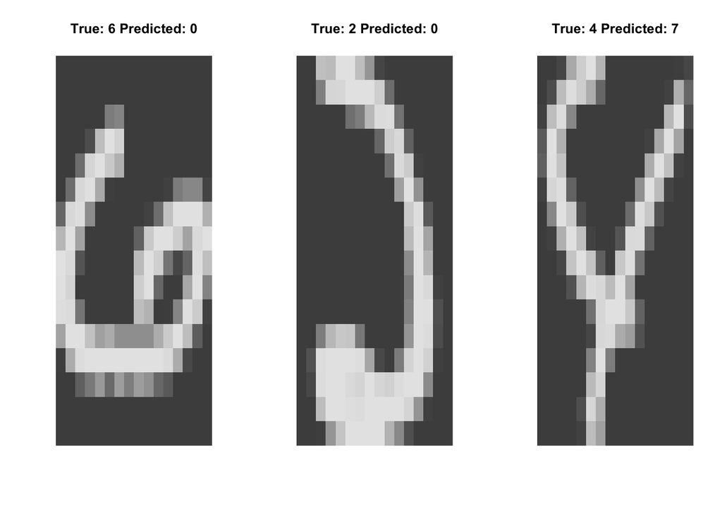

```r
wrong <- which(pred_euclidean != y_test)

par(mfrow = c(1, 3))

for (i in wrong[1:3]) {

  image_matrix <- matrix(
    X_test[i, ],
    nrow = 16,
    ncol = 16,
    byrow = TRUE
  )

  image(
    t(image_matrix[16:1, ]),
    col = gray.colors(256),
    axes = FALSE,
    main = paste(
      "True:", y_test[i],
      "Predicted:", pred_euclidean[i]
    )
  )
}
```

**Show the workflow**

```r
par(mfrow = c(1, 1))
```

The 5NN classifier calculates the distance between each test observation and every training observation using either Euclidean or Manhattan distance. It then selects the five closest training observations and predicts the digit using a majority vote. If observations are tied in distance, the observation with the smaller training row number is selected first. If there is a tie in the majority vote, the smaller digit is predicted.

Using Euclidean distance, the 5NN classifier made 61 classification errors out of 500 test observations. Using Manhattan distance, the classifier made 69 errors. Therefore, Euclidean distance performed slightly better on this test set. The confusion matrices above show the classification results for each digit.

The three images above show examples that were incorrectly classified using Euclidean distance. Some of the digits have shapes that look similar to other digits, which can cause their nearest neighbors to belong to the wrong class. Overall, Euclidean distance performed slightly better than Manhattan distance, with 61 errors compared to 69. The two distance measures can produce different nearest neighbors because Euclidean distance uses the square root of the sum of squared differences between pixel values, while Manhattan distance uses the sum of absolute differences. For this dataset, Euclidean distance resulted in slightly better classification performance.

## Question 5: Create a plot-formatting skill

Create a short `SKILL.md` file for improving the formatting of STAT 432 homework plots. You may use AI to help write it.

1. Include a title, a description, and a few formatting rules. The description should limit the skill to STAT 432 homework plot improvements and require an explicit request to use it. Your rules should address margins, titles, axes, labels, colors, and sizes for plots produced in R or Python. Keep them portable: do not refer to specific homework questions.
2. Ask your agent to install the skill. Explicitly call it to improve the plot from Question 1, then compare the original and revised versions. Do you like the changes? You may revise the skill and test it a couple more times, or uninstall it if it remains unhelpful.
3. Append your final `SKILL.md` content to your submission and briefly explain your choices and experience.

### Solution: Question 5

Skill

I prefer the revised plot because the formatting makes it easier to read and understand. The descriptive title and clearer axis labels make the purpose of the plot more obvious, while the larger text and points make the values easier to see. I also like having the legend above the plot with more descriptive labels. The changes improve the appearance of the plot without changing any of the underlying data or results.

I designed the skill to focus on making plots easier to read without changing the underlying analysis. I included rules for titles, axis labels, margins, colors, font sizes, legends, and figure size because these are important parts of making a plot clear and readable. I also specified that the skill should only be used for STAT 432 homework plots when explicitly requested so that it would not automatically change other plots. Overall, the skill worked well because it improved the formatting of my Question 1 plot while keeping the original data and results unchanged.

```markdown
---
name: stat432-plot-formatting
description: Use only when explicitly requested to improve the formatting of a STAT 432 homework plot.
---

# STAT 432 Plot Formatting

- Keep the original data, calculations, and statistical meaning of the plot unchanged.
- Use enough margin so titles, axis labels, tick labels, and legends are not cut off.
- Add a short and descriptive title when appropriate.
- Clearly label both axes and use readable tick marks and labels.
- Use colors that are easy to distinguish and avoid unnecessary colors.
- Use readable font sizes for titles, axis labels, tick labels, and legends.
- Choose a figure size that makes the plot easy to read without taking up unnecessary space.
- Apply these formatting rules to existing R or Python plotting code without changing the underlying analysis.
```